# Krzysztof Jankowski HW5

## Task 1

### Problem statement

We have a model $$ f(x_1, x_2) = (x_1 + x_2) ^ 2 $$ and $$ x_1, x_2 \sim U[-1, 1], \ x_1 = x_2 $$ We will calculate the PD profile for variable $x_1$ in this model.

### Calculation

$$ g_1^{PD}(z) = E_{X_2}[z^2 + 2zx_2 + x_2^2] = $$ $$ = z^2 + 2zE_{X_2}[x_2] + E_{X_2}[x_2^2] = $$ $$ = z^2 + 2z \cdot 0 + \frac{1}{3} = z^2 + \frac{1}{3}$$ In last steps we used the fact that because $x_1 \sim U[-1, 1]$ then $E_{X_2}[x_2] = 0$ and $E_{X_2}[x_2^2] = \int_{-1}^{1} x_2^2 \cdot f_{X_2}(x_2) \,dx_2 = \int_{-1}^{1} \frac{x_2^2}{2} \,dx = \frac{1^3}{6} - \frac{(-1)^3}{6} = 1/3$

## Task 2

### Dataset

I used the dataset from previous homework - pc1 dataset from openml. I preprocessed it using a StandardScaler and LabelEncoder for the labels to be in [0, 1] set. I also split the dataset into train and test sets with test set consisting of 33% of the data.

### Models

I trained 2 tree-based ensemble models - RandomForest and XGBoost. I used the default hyperparameters for both models. The performance of the models on the test set is presented below:

[output not shown]

XGBoost performs better in all metrics except auc. I also tested the models' predictions on 2 randomly selected observations - one with ground truth class 1 and one with ground truth class 0. The observations (rounded values) are presented below:

| id | loc | v(g) | ev(g) | iv(G) | N | V | L | D | I | E | B | T | lOCode | lOComment | locCodeAndComment | lOBlank | uniq_Op | uniq_Opnd | total_Op | total_Opnd | branchCount |
| --- | --- | --- | --- | --- | --- | --- | --- | --- | --- | --- | --- | --- | --- | --- | --- | --- | --- | --- | --- | --- | --- |
| 48 | -0.4927 | -0.5037 | -0.3175 | -0.3628 | -0.4431 | -0.3714 | 0.1402 | -0.5448 | -0.3244 | -0.1637 | -0.3671 | -0.1637 | -0.4897 | -0.3516 | -0.2826 | 0.0207 | -0.0376 | -0.3062 | -0.4343 | -0.4509 | -0.5187 |
| 1037 | -0.3509 | -0.2804 | -0.3175 | -0.3628 | -0.4836 | -0.4082 | 0.5486 | -0.6568 | -0.4228 | -0.1667 | -0.4068 | -0.1667 | -0.3407 | -0.4467 | -0.2826 | -0.4673 | -0.6490 | -0.5129 | -0.4612 | -0.5089 | -0.3373 |

Both models predicted the class correctly for both observations.

| observation id | RandomForest | XGBoost | ground truth |
| --- | --- | --- | --- |
| 48 | 1 | 1 | 1 |
| 1037 | 0 | 0 | 0 |

### Ceteris Paribus profiles

Plots below show the calculated CP profiles for 2 sample observations (id 48 and 1037 mentioned previously) for RandomForest and XGBoost.

[figure not shown]

#### CP comments

In general profiles for respective variables for RandomForest and XGBoost are similar, however there is a tendency that for XGBoost there are more fluctuations on the plots. As all plots show the profiles for both observations we can also see for which variables the CP profiles are different for both observations (I will focus on RandomForest now).

Variables for which the CP profile for samples observations for RandomForest have different CP (increase vs decrease):

- loc (visible)
- N (slightly visible)
- L (slightly visible)
- I (visible)
- IOCode (visible)
- IOComment (visible)
- IOCodeAndComment (slightly visible)
- uniq_Opnd (visible)
- total_Opnd (slightly visible)

### CP and PDP comparison for RandomForest

Plot below compares the CP and PDP profiles for RandomForest. Thin grey lines represent the CP profiles (plotted with N=30, as Plotly was unfortunately crashing with bigger values as the HTML output was growing) and the blue line represents the PDP profile.

[figure not shown]

There is a general tendency that CP profiles have similar curvature but different placement on the 'y' axis with more profiles being quite close to PDP profile.

### PDP comparison between models

The following plots illustrate the PDP for RandomForest and XGBoost.

[figure not shown]

#### PDP comments

PDP profiles in both cases are similar in case of global tendencies e.g. the values increase or decrease similarly in both models, however there are some differences as it comes to more "local" fluctuations where some plots are more "noisy" than others. In general all values for XGBoost are lower. This is especially visible for the following variables:

- loc (increases more noisily in RandomForest and also increases much more than in XGBoost)
- N (has similar trend as in XGBoost but is more noisy)
- I (has similar trend but is more noisy in XGBoost)
- B (has similar trend but is more noisy in XGBoost)
- IOComment (increases faster in RandomForest)

### Bonus

I also implemented CP profiles and PDP profiles as a small class. The implementation is presented at the end of the Appendix. Below I present the plots for the CP and PDP profiles for the same observations as before (visualization for the first one and variable 'loc' only).

[figure not shown]

By looking at the plots we can see that they are very similar to those generated by Dalex package.

## Appendix

### Dataset

```python
# uncomment if you don't have dalex installed
# !pip install dalex
```

```python
from numpy import ndarray, dtype
from sklearn.preprocessing import LabelEncoder, StandardScaler
from sklearn.datasets import fetch_openml
from sklearn.model_selection import train_test_split
import pandas as pd

X, y = fetch_openml('pc1', return_X_y=True)
standard_scaler = StandardScaler()
standard_scaler.fit(X)
X = pd.DataFrame(standard_scaler.transform(X), columns=X.columns)

le = LabelEncoder()
y = le.fit_transform(y)

display(X.head())
display(y[:5])
print(X.shape, y.shape)

X_train, X_test, y_train, y_test = train_test_split(X, y, test_size=0.33, random_state=42)
```

|  | loc | v(g) | ev(g) | iv(G) | N | V | L | D | I | E | B | T | lOCode | lOComment | locCodeAndComment | lOBlank | uniq_Op | uniq_Opnd | total_Op | total_Opnd | branchCount |
| --- | --- | --- | --- | --- | --- | --- | --- | --- | --- | --- | --- | --- | --- | --- | --- | --- | --- | --- | --- | --- | --- |
| 0 | -0.631622 | -0.459046 | -0.245601 | -0.300256 | -0.588566 | -0.462872 | 7.969369 | -0.863205 | -0.893495 | -0.168975 | 2.110355 | -0.168846 | -0.608907 | -0.256439 | 0.315512 | -0.385967 | -1.480420 | -0.678168 | -0.584789 | -0.576122 | -0.494553 |
| 1 | -0.634457 | -0.503714 | -0.317476 | -0.362765 | -0.590087 | -0.463071 | 5.926964 | -0.881576 | -0.901977 | -0.168977 | 1.515760 | -0.168878 | -0.638705 | -0.351553 | 0.016450 | -0.467296 | -1.504874 | -0.685056 | -0.586581 | -0.578440 | -0.518747 |
| 2 | 1.917424 | 0.389648 | 0.041900 | -0.206493 | 1.017028 | 0.920890 | -0.608731 | 0.752212 | 1.203377 | 0.170082 | 0.921166 | 0.170082 | 1.715323 | 3.738348 | 3.007069 | 1.972589 | 1.918722 | 1.553365 | 1.124079 | 0.870503 | 0.449002 |
| 3 | 2.427800 | 1.729691 | 0.401277 | 2.293854 | 1.336423 | 1.224661 | -0.608731 | 0.794465 | 1.608220 | 0.254797 | 1.218463 | 0.254796 | 2.221885 | 3.453006 | 3.306131 | 1.403282 | 1.796451 | 1.863300 | 1.455463 | 1.171883 | 1.719172 |
| 4 | 13.656075 | 11.221663 | 6.870055 | 12.295243 | 11.263018 | 13.253154 | -0.812972 | 3.706872 | 6.775907 | 9.044464 | 13.209453 | 9.044465 | 12.949100 | 6.306425 | 14.072361 | 3.436519 | 6.198217 | 12.952091 | 11.916457 | 10.329205 | 10.186974 |

```
array([0, 1, 1, 1, 1])
```

```
(1109, 21) (1109,)
```

### Selected observations

```python
import pandas as pd
import numpy as np

# set seed for reproducibility
pd.set_option('display.max_columns', None)
np.random.seed(42)
num_of_sampled_observations = 1

observations_with_target_true = X_train[y_train == 1]
observations_with_target_false = X_train[y_train == 0]

# sample 2 observations randomly from each class
labels = [1, 0]
sampled_observations = pd.concat([observations_with_target_true.sample(num_of_sampled_observations),
                                  observations_with_target_false.sample(num_of_sampled_observations)])
display(sampled_observations)
```

|  | loc | v(g) | ev(g) | iv(G) | N | V | L | D | I | E | B | T | lOCode | lOComment | locCodeAndComment | lOBlank | uniq_Op | uniq_Opnd | total_Op | total_Opnd | branchCount |
| --- | --- | --- | --- | --- | --- | --- | --- | --- | --- | --- | --- | --- | --- | --- | --- | --- | --- | --- | --- | --- | --- |
| 48 | -0.492686 | -0.503714 | -0.317476 | -0.362765 | -0.443064 | -0.371399 | 0.140151 | -0.544776 | -0.324397 | -0.163674 | -0.367122 | -0.163674 | -0.489716 | -0.351553 | -0.282612 | 0.020681 | -0.037619 | -0.306246 | -0.434323 | -0.450933 | -0.518747 |
| 1037 | -0.350915 | -0.280374 | -0.317476 | -0.362765 | -0.483622 | -0.408222 | 0.548632 | -0.656839 | -0.422780 | -0.166691 | -0.406762 | -0.166691 | -0.340727 | -0.446667 | -0.282612 | -0.467296 | -0.648975 | -0.512870 | -0.461192 | -0.508891 | -0.337294 |

### Models

```python
from sklearn.ensemble import RandomForestClassifier
import dalex as dx
from xgboost import XGBClassifier

def dx_predict_proba(model, df):
    return model.predict_proba(df)[:, 1]

models = {
    'RandomForest': RandomForestClassifier(),
    'XGBoost': XGBClassifier(),
}

explainers = {}

for model_name, model in models.items():
    print(f'Fitting {model_name}...')
    model.fit(X_train, y_train)

    print(f'{model_name} predictions')
    print(f'Predicted classes {model.predict(sampled_observations)}.')
    print(f'Ground truth classes {num_of_sampled_observations * [1] + num_of_sampled_observations * [0]}.')

    explainer = dx.Explainer(model, X_test, y_test, predict_function=dx_predict_proba, label=model_name)
    display(explainer.model_performance())
    explainers[model_name] = explainer
```

```
Fitting RandomForest...
RandomForest predictions
Predicted classes [1 0].
Ground truth classes [1, 0].
Preparation of a new explainer is initiated

  -> data              : 366 rows 21 cols
  -> target variable   : 366 values
  -> model_class       : sklearn.ensemble._forest.RandomForestClassifier (default)
  -> label             : RandomForest
  -> predict function  : <function dx_predict_proba at 0x7f1e51350160> will be used
  -> predict function  : Accepts pandas.DataFrame and numpy.ndarray.
  -> predicted values  : min = 0.0, mean = 0.0707, max = 0.98
  -> model type        : classification will be used (default)
  -> residual function : difference between y and yhat (default)
  -> residuals         : min = -0.85, mean = 0.0112, max = 1.0
  -> model_info        : package sklearn

A new explainer has been created!
```

|  | recall | precision | f1 | accuracy | auc |
| --- | --- | --- | --- | --- | --- |
| RandomForest | 0.166667 | 0.625 | 0.263158 | 0.923497 | 0.821925 |

```
Fitting XGBoost...
XGBoost predictions
Predicted classes [1 0].
Ground truth classes [1, 0].
Preparation of a new explainer is initiated

  -> data              : 366 rows 21 cols
  -> target variable   : 366 values
  -> model_class       : xgboost.sklearn.XGBClassifier (default)
  -> label             : XGBoost
  -> predict function  : <function dx_predict_proba at 0x7f1e51350160> will be used
  -> predict function  : Accepts pandas.DataFrame and numpy.ndarray.
  -> predicted values  : min = 2.28e-05, mean = 0.0377, max = 0.946
  -> model type        : classification will be used (default)
  -> residual function : difference between y and yhat (default)
  -> residuals         : min = -0.946, mean = 0.0442, max = 1.0
  -> model_info        : package xgboost

A new explainer has been created!
```

|  | recall | precision | f1 | accuracy | auc |
| --- | --- | --- | --- | --- | --- |
| XGBoost | 0.233333 | 0.636364 | 0.341463 | 0.92623 | 0.805208 |

### CP profiles

```python
cps = [explainer.predict_profile(new_observation=sampled_observations) for explainer in explainers.values()]
# Uncomment if you want to see the plot. Commented out as HTML output here is big.
# cps[0].plot(cps[1])
```

### PDP profiles

```python
pdps = [explainer.model_profile() for explainer in explainers.values()]
# Uncomment if you want to see the plot. Commented out as HTML output here is big.
# pdps[0].plot(pdps[1])
```

```python
# Run carefully as plotly crashes with big N. Safe options are 5-10. N=30 can be run but the results can be seen only when the notebook is converted to HTML form.
pdp_small = explainers['RandomForest'].model_profile(N=30)
# Uncomment if you want to see the plot. Commented out as HTML output here is big.
# pdp_small.plot(geom="profiles", title="Partial Dependence Plot with individual profiles", size=3)
```

### Bonus - own implementation of CP and PDP profiles.

```python
from typing import Protocol


class ScikitModel(Protocol):
    def fit(self, X, y, sample_weight=None): ...
    def predict_proba(self, X): ...
    def score(self, X, y, sample_weight=None): ...
```

```python
from matplotlib import pyplot as plt
from typing import Tuple


class MyProfile:

    def __init__(self, model: ScikitModel, X: pd.DataFrame, num_points: int = 50, figsize: Tuple[int, int] = (10, 3)):
        self.model = model
        self.num_points = num_points
        self.X = X
        self.figsize = figsize

    def cp_profile(self, observation: pd.DataFrame, variable: str) -> Tuple[np.ndarray, pd.DataFrame]:
        value = observation[variable].values[0]

        # value on x axis with also the value from the observation.
        test_values = np.linspace(self.X[variable].min(), self.X[variable].max(), self.num_points - 1)
        index_to_insert = np.searchsorted(test_values, value)
        test_values = np.insert(test_values, index_to_insert, value)

        new_observations = pd.concat([observation] * self.num_points, ignore_index=True)
        new_observations[variable] = test_values
        new_models_predictions = self.model.predict_proba(new_observations)[:, 1]
        return test_values, new_models_predictions

    def pdp_profile(self, variable: str, N: int = 30) -> tuple[np.ndarray, np.ndarray, np.ndarray]:
        test_values = np.linspace(self.X[variable].min(), self.X[variable].max(), self.num_points)
        # sample N observations from the dataset
        sampled_observations = self.X.sample(N)
        # iterate rows of sampled_observations
        cp_profiles = []
        for index, row in sampled_observations.iterrows():
            _, cp_profile = self.cp_profile(row.to_frame().T, variable)
            cp_profiles.append(cp_profile)

        # concatenate cp_profiles into one pandas
        cp_profiles = np.array(cp_profiles)
        pdp_profile = cp_profiles.mean(axis=0)

        return test_values, cp_profiles, pdp_profile

    def plot_cp_profile(self, observation: pd.DataFrame, variable: str,
                        values: Tuple[np.ndarray, pd.DataFrame]) -> None:
        # set figsize
        plt.figure(figsize=self.figsize)
        model_prediction = self.model.predict_proba(observation)[:, 1]
        value = observation[variable].values[0]
        plt.plot(values[0], values[1], label='CP profile')
        plt.plot(value, model_prediction, 'ro', label='Observation')
        plt.title(f'CP profile for variable {variable}.')
        # add legend
        plt.legend()

    def plot_pdp_profile(self, variable: str, values: Tuple[np.ndarray, np.ndarray, np.ndarray]) -> None:
        plt.figure(figsize=self.figsize)
        plt.plot(values[0], values[1].T, 'grey', alpha=0.4, linewidth=1)
        plt.plot(values[0], values[2], 'lightblue', linewidth=5, label='PDP profile')
        plt.title(f'PDP profile for variable {variable}.')
        plt.legend()
```

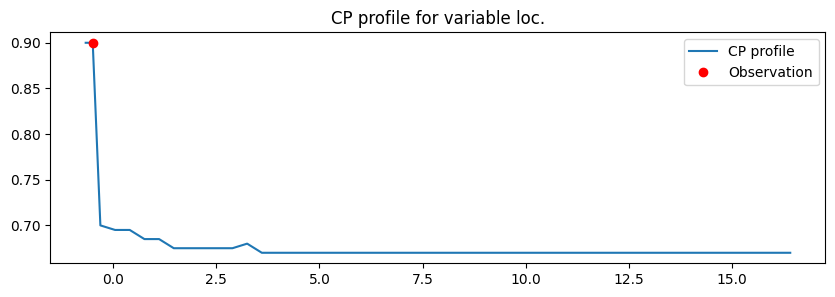

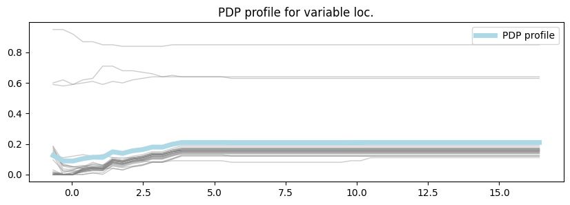

```python
my_profile = MyProfile(models['RandomForest'], X_train)

test_values, cp_profile = my_profile.cp_profile(sampled_observations.head(1), variable='loc')
my_profile.plot_cp_profile(sampled_observations.head(1), variable='loc', values=(test_values, cp_profile))

x, cp_profiles, pdp_profile = my_profile.pdp_profile('loc')
my_profile.plot_pdp_profile('loc', (x, cp_profiles, pdp_profile))
```